# Vessel pressure rasters — mean by OHI region

2026-10-12

For each **1 km vessel pressure GeoTIFF**, compute the **mean cell value** within every **marine** OHI Gulf of California region (`spatial/ohi_regions/goc_ohi_rgns.shp`).

**Two raster versions:**

[output not shown]

**Outputs:** one CSV per pressure layer with columns:

| Column | Description |
| --- | --- |
| `pressure_name` | Short pressure identifier |
| `ohi_rgn` | Region ID from shapefile (`rgn_id`, e.g. `Region_1`) |
| `year` | Calendar year from the raster filename |
| `mean` | Mean uncapped raster value in that region (NA cells excluded) |

**Rasters read from:** `/home/shares/ohi/OHI_GOC/goal_prep/pressures/vessels/`

```r
library(tidyverse)
library(here)
library(sf)
library(terra)
```

```r
figures_dir <- here("_pressures/vessels/figures")
```

## OHI regions (marine only)

Vessel pressures are marine; land polygons in the shapefile are dropped.

```r
ohi_rgns <- st_read(here("spatial/ohi_regions/goc_ohi_rgns.shp"), quiet = TRUE)

ohi_rgns_marine <- ohi_rgns %>%
  filter(location == "marine") %>%
  arrange(rgn_id)

ohi_rgns_marine %>%
  st_drop_geometry() %>%
  select(rgn_id, estado, ecorgn)
```

```
##     rgn_id              estado         ecorgn
## 1 Region_1     Baja_California     Upper_Gulf
## 2 Region_2     Baja_California Midriff_Region
## 3 Region_3 Baja_California_Sur   Central_Gulf
## 4 Region_4 Baja_California_Sur  Southern_Gulf
## 5 Region_5              Sonora     Upper_Gulf
## 6 Region_6              Sonora Midriff_Region
## 7 Region_7              Sonora   Central_Gulf
## 8 Region_8             Sinaloa  Southern_Gulf
## 9 Region_9             Nayarit  Southern_Gulf
```

```r
region_labels <- ohi_rgns_marine %>%
  st_drop_geometry() %>%
  transmute(
    ohi_rgn = rgn_id,
    region_label = paste0(rgn_id, " · ", ecorgn)
  )

region_palette <- setNames(
  hcl.colors(nrow(region_labels), palette = "Zissou1"),
  region_labels$region_label
)
```

## Pressure layer definitions

Edit paths here if filenames or folders change.

```r
PRESSURE_ROOT <- "/home/shares/ohi/OHI_GOC/goal_prep/pressures/vessels"
VIZ_YEAR <- 2024L

pressures <- tibble(
  pressure_name = c(
    "vessel_traffic",
    "benthic_destructive_fishing",
    "ghost_gear"
  ),
  subdir = c(
    "vessel_traffic",
    "benthic_destructive_fishing",
    "ghost_gear"
  ),
  file_stub = c(
    "vms_hours",
    "destructive_fishing_hours",
    "ghost_gear_risk"
  ),
  plot_title = c(
    "Vessel traffic hours (capped)",
    "Bottom-destructive fishing hours (capped)",
    "Ghost gear risk (capped)"
  ),
  trend_title = c(
    "Vessel traffic by OHI region",
    "Bottom-destructive fishing by OHI region",
    "Ghost gear risk by OHI region"
  ),
  ylab = c(
    "Mean vessel-hours per cell",
    "Mean bottom-trawl hours per cell",
    "Mean ghost risk-hours per cell"
  )
)

pressures
```

```
## # A tibble: 3 × 6
##   pressure_name               subdir      file_stub plot_title trend_title ylab
##   <chr>                       <chr>       <chr>     <chr>      <chr>       <chr>
## 1 vessel_traffic              vessel_tra… vms_hours Vessel tr… Vessel tra… Mean…
## 2 benthic_destructive_fishing benthic_de… destruct… Bottom-de… Bottom-des… Mean…
## 3 ghost_gear                  ghost_gear  ghost_ge… Ghost gea… Ghost gear… Mean…
```

```r
## Uncapped: vms_hours_2024_1km.tif | Capped: vms_hours_2024_1km_capped.tif
pressure_tif_path <- function(subdir, file_stub, year, capped = FALSE) {
  dir_path <- file.path(PRESSURE_ROOT, subdir)
  suffix <- if (capped) "_1km_capped.tif" else "_1km.tif"
  path <- file.path(dir_path, sprintf("%s_%s%s", file_stub, year, suffix))

  if (file.exists(path)) {
    return(path)
  }
  NA_character_
}

## Years with an uncapped raster (used for CSV summaries).
available_years <- function(subdir, file_stub, capped = FALSE) {
  dir_path <- file.path(PRESSURE_ROOT, subdir)
  pattern <- if (capped) {
    paste0("^", file_stub, "_[0-9]{4}_1km_capped\\.tif$")
  } else {
    paste0("^", file_stub, "_[0-9]{4}_1km\\.tif$")
  }
  files <- list.files(dir_path, pattern = pattern)
  as.integer(str_extract(files, "[0-9]{4}"))
}

## Mean raster value per polygon. terra::zonal rows match polygon order in regions_vect.
mean_by_ohi_region <- function(raster_path, regions_sf) {
  r <- rast(raster_path)
  regions_ll <- st_transform(regions_sf, crs(r))
  regions_vect <- vect(regions_ll)

  zonal_out <- zonal(r, regions_vect, fun = "mean", na.rm = TRUE)
  zonal_df <- as_tibble(zonal_out)

  if ("ID" %in% names(zonal_df)) {
    zonal_df <- zonal_df %>%
      rename(zone_id = ID, mean = -ID)
  } else {
    if (nrow(zonal_df) != nrow(regions_sf)) {
      stop(
        "Zonal row count (", nrow(zonal_df), ") does not match regions (",
        nrow(regions_sf), ") for ", basename(raster_path)
      )
    }
    zonal_df <- tibble(
      zone_id = seq_len(nrow(zonal_df)),
      mean = zonal_df[[1]]
    )
  }

  regions_sf %>%
    mutate(zone_id = row_number()) %>%
    st_drop_geometry() %>%
    select(zone_id, ohi_rgn = rgn_id) %>%
    left_join(zonal_df, by = "zone_id") %>%
    select(ohi_rgn, mean)
}
```

## Summarize each pressure (uncapped rasters → CSV)

```r
pressure_tables <- map(seq_len(nrow(pressures)), function(i) {
  p <- pressures[i, ]
  years <- sort(available_years(p$subdir, p$file_stub, capped = FALSE))

  message(
    "\n=== ", p$pressure_name, " (uncapped) ===\n",
    "Years found: ", paste(years, collapse = ", ")
  )

  if (length(years) == 0) {
    warning("No uncapped rasters found for ", p$pressure_name)
    return(NULL)
  }

  map_dfr(years, function(year) {
    tif <- pressure_tif_path(p$subdir, p$file_stub, year, capped = FALSE)
    if (is.na(tif)) {
      warning("Missing uncapped raster for ", p$pressure_name, " year ", year)
      return(NULL)
    }

    message("  ", year, ": ", basename(tif))

    mean_by_ohi_region(tif, ohi_rgns_marine) %>%
      mutate(
        pressure_name = p$pressure_name,
        year = year,
        .before = ohi_rgn
      )
  })
})
```

```
##
## === vessel_traffic (uncapped) ===
## Years found: 2007, 2008, 2009, 2010, 2011, 2012, 2013, 2014, 2015, 2016, 2017, 2018, 2019, 2020, 2021, 2022, 2023, 2024, 2025
```

```
##   2007: vms_hours_2007_1km.tif
```

```
##   2008: vms_hours_2008_1km.tif
```

```
##   2009: vms_hours_2009_1km.tif
```

```
##   2010: vms_hours_2010_1km.tif
```

```
##   2011: vms_hours_2011_1km.tif
```

```
##   2012: vms_hours_2012_1km.tif
```

```
##   2013: vms_hours_2013_1km.tif
```

```
##   2014: vms_hours_2014_1km.tif
```

```
##   2015: vms_hours_2015_1km.tif
```

```
##   2016: vms_hours_2016_1km.tif
```

```
##   2017: vms_hours_2017_1km.tif
```

```
##   2018: vms_hours_2018_1km.tif
```

```
##   2019: vms_hours_2019_1km.tif
```

```
##   2020: vms_hours_2020_1km.tif
```

```
##   2021: vms_hours_2021_1km.tif
```

```
##   2022: vms_hours_2022_1km.tif
```

```
##   2023: vms_hours_2023_1km.tif
```

```
##   2024: vms_hours_2024_1km.tif
```

```
##   2025: vms_hours_2025_1km.tif
```

```
##
## === benthic_destructive_fishing (uncapped) ===
## Years found: 2007, 2008, 2009, 2010, 2011, 2012, 2013, 2014, 2015, 2016, 2017, 2018, 2019, 2020, 2021, 2022, 2023, 2024, 2025
```

```
##   2007: destructive_fishing_hours_2007_1km.tif
```

```
##   2008: destructive_fishing_hours_2008_1km.tif
```

```
##   2009: destructive_fishing_hours_2009_1km.tif
```

```
##   2010: destructive_fishing_hours_2010_1km.tif
```

```
##   2011: destructive_fishing_hours_2011_1km.tif
```

```
##   2012: destructive_fishing_hours_2012_1km.tif
```

```
##   2013: destructive_fishing_hours_2013_1km.tif
```

```
##   2014: destructive_fishing_hours_2014_1km.tif
```

```
##   2015: destructive_fishing_hours_2015_1km.tif
```

```
##   2016: destructive_fishing_hours_2016_1km.tif
```

```
##   2017: destructive_fishing_hours_2017_1km.tif
```

```
##   2018: destructive_fishing_hours_2018_1km.tif
```

```
##   2019: destructive_fishing_hours_2019_1km.tif
```

```
##   2020: destructive_fishing_hours_2020_1km.tif
```

```
##   2021: destructive_fishing_hours_2021_1km.tif
```

```
##   2022: destructive_fishing_hours_2022_1km.tif
```

```
##   2023: destructive_fishing_hours_2023_1km.tif
```

```
##   2024: destructive_fishing_hours_2024_1km.tif
```

```
##   2025: destructive_fishing_hours_2025_1km.tif
```

```
##
## === ghost_gear (uncapped) ===
## Years found: 2007, 2008, 2009, 2010, 2011, 2012, 2013, 2014, 2015, 2016, 2017, 2018, 2019, 2020, 2021, 2022, 2023, 2024, 2025
```

```
##   2007: ghost_gear_risk_2007_1km.tif
```

```
##   2008: ghost_gear_risk_2008_1km.tif
```

```
##   2009: ghost_gear_risk_2009_1km.tif
```

```
##   2010: ghost_gear_risk_2010_1km.tif
```

```
##   2011: ghost_gear_risk_2011_1km.tif
```

```
##   2012: ghost_gear_risk_2012_1km.tif
```

```
##   2013: ghost_gear_risk_2013_1km.tif
```

```
##   2014: ghost_gear_risk_2014_1km.tif
```

```
##   2015: ghost_gear_risk_2015_1km.tif
```

```
##   2016: ghost_gear_risk_2016_1km.tif
```

```
##   2017: ghost_gear_risk_2017_1km.tif
```

```
##   2018: ghost_gear_risk_2018_1km.tif
```

```
##   2019: ghost_gear_risk_2019_1km.tif
```

```
##   2020: ghost_gear_risk_2020_1km.tif
```

```
##   2021: ghost_gear_risk_2021_1km.tif
```

```
##   2022: ghost_gear_risk_2022_1km.tif
```

```
##   2023: ghost_gear_risk_2023_1km.tif
```

```
##   2024: ghost_gear_risk_2024_1km.tif
```

```
##   2025: ghost_gear_risk_2025_1km.tif
```

```r
names(pressure_tables) <- pressures$pressure_name
```

## Preview summary tables

```r
walk(pressure_tables, ~ print(.x %>% arrange(year, ohi_rgn)))
```

```
##      pressure_name year  ohi_rgn       mean
## 1   vessel_traffic 2007 Region_1  5.2525625
## 2   vessel_traffic 2007 Region_2  2.0039289
## 3   vessel_traffic 2007 Region_3  2.0700536
## 4   vessel_traffic 2007 Region_4  0.6368910
## 5   vessel_traffic 2007 Region_5  4.1070651
## 6   vessel_traffic 2007 Region_6  4.7761416
## 7   vessel_traffic 2007 Region_7 11.7435370
## 8   vessel_traffic 2007 Region_8 19.9847091
## 9   vessel_traffic 2007 Region_9  4.6088046
## 10  vessel_traffic 2008 Region_1  6.7061899
## 11  vessel_traffic 2008 Region_2  2.1077208
## 12  vessel_traffic 2008 Region_3  2.1947352
## 13  vessel_traffic 2008 Region_4  0.4587642
## 14  vessel_traffic 2008 Region_5  4.5840202
```

[output cut: 501 more lines]

## Save one CSV per pressure

Files written to `_pressures/vessels/data/` (means from **uncapped** rasters).

```r
iwalk(pressure_tables, function(tbl, name) {
  if (is.null(tbl) || nrow(tbl) == 0) {
    message("Skipping ", name, " (no data)")
    return(invisible(NULL))
  }

  out_path <- here(
    "_pressures/vessels/data",
    paste0(name, "_mean_by_ohi_rgn.csv")
  )

  tbl %>%
    select(pressure_name, ohi_rgn, year, mean) %>%
    arrange(year, ohi_rgn) %>%
    write_csv(out_path)

  message("Wrote ", nrow(tbl), " rows → ", out_path)
})
```

```
## Wrote 171 rows → /home/frazier/ohi_goc_prep/_pressures/vessels/data/vessel_traffic_mean_by_ohi_rgn.csv
```

```
## Wrote 171 rows → /home/frazier/ohi_goc_prep/_pressures/vessels/data/benthic_destructive_fishing_mean_by_ohi_rgn.csv
```

```
## Wrote 171 rows → /home/frazier/ohi_goc_prep/_pressures/vessels/data/ghost_gear_mean_by_ohi_rgn.csv
```

## Line plots: regional mean vs year

One line per **marine** OHI region (uncapped means). Points mark each year.

```r
region_labels <- ohi_rgns_marine %>%
  st_drop_geometry() %>%
  transmute(
    ohi_rgn = rgn_id,
    region_label = paste0(rgn_id, " · ", ecorgn)
  )

pressure_trends <- imap(pressure_tables, function(tbl, name) {
  if (is.null(tbl) || nrow(tbl) == 0) {
    return(NULL)
  }
  tbl %>%
    left_join(region_labels, by = "ohi_rgn") %>%
    mutate(region_label = factor(region_label, levels = region_labels$region_label))
}) %>%
  compact()


plot_pressure_trends <- function(tbl, title, ylab) {
  ggplot(tbl, aes(x = year, y = mean, color = region_label, group = region_label)) +
    geom_line(linewidth = 0.85, alpha = 0.95) +
    geom_point(size = 2.4, alpha = 0.95) +
    scale_x_continuous(breaks = scales::breaks_width(1)) +
    scale_color_manual(values = region_palette, name = "OHI region") +
    labs(
      title = title,
      subtitle = "Mean uncapped raster value per 1 km cell within each region",
      x = "Year",
      y = ylab
    ) +
    theme_minimal(base_size = 12) +
    theme(
      plot.title = element_text(face = "bold", size = 13),
      plot.subtitle = element_text(color = "grey35", size = 10),
      panel.grid.minor = element_blank(),
      panel.grid.major = element_line(color = "grey92"),
      legend.key.height = unit(0.45, "cm"),
      legend.text = element_text(size = 9)
    )
}
```

```
## Wrote figure → /home/frazier/ohi_goc_prep/_pressures/vessels/figures/vessel_traffic_mean_by_ohi_rgn_trend.png
```

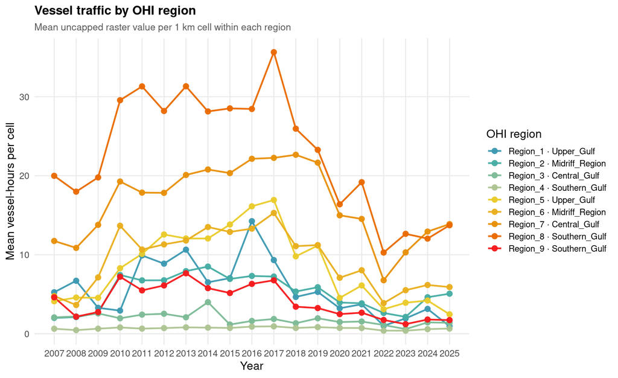

```
## Wrote figure → /home/frazier/ohi_goc_prep/_pressures/vessels/figures/benthic_destructive_fishing_mean_by_ohi_rgn_trend.png
```

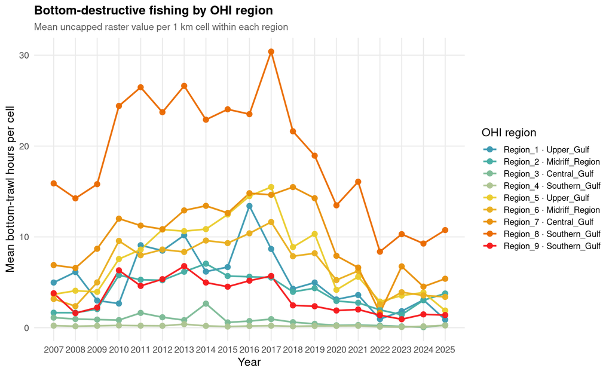

```
## Wrote figure → /home/frazier/ohi_goc_prep/_pressures/vessels/figures/ghost_gear_mean_by_ohi_rgn_trend.png
```

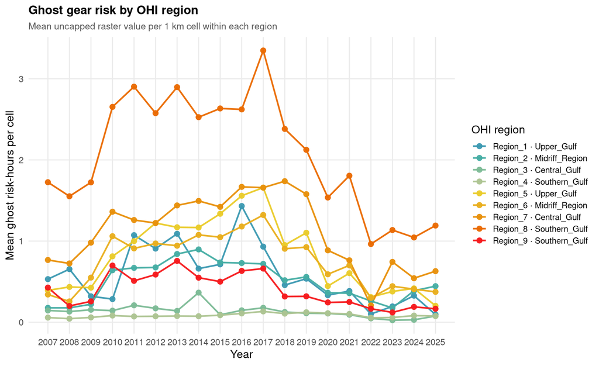

```r
walk(seq_len(nrow(pressures)), function(i) {
  p <- pressures[i, ]
  tbl <- pressure_trends[[p$pressure_name]]

  if (is.null(tbl)) {
    message("No trend data for ", p$pressure_name)
    return(invisible(NULL))
  }

  p_plot <- plot_pressure_trends(tbl, p$trend_title, p$ylab)
  out_path <- file.path(figures_dir, paste0(p$pressure_name, "_mean_by_ohi_rgn_trend.png"))

  ggsave(
    out_path,
    plot = p_plot,
    width = 9,
    height = 5.5,
    dpi = 300,
    bg = "white"
  )
  message("Wrote figure → ", out_path)

  print(p_plot)
})
```

## Hydrocarbon pollution risk (rescaled vessel traffic)

Rescale **vessel traffic** regional means to **0–1** for use as hydrocarbon pollution risk:

1. Reference = mean of the **top 5** regional mean values across all regions and years.
2. `pressure = min(mean / reference, 1)`.

```r
vessel_traffic_tbl <- read_csv(here("_pressures/vessels/data/vessel_traffic_mean_by_ohi_rgn.csv"))
top5_means <- vessel_traffic_tbl %>%
  arrange(desc(mean)) %>%
  slice_head(n = 5)

hydrocarbon_ref <- mean(top5_means$mean)

hydrocarbon_pollution_risk <- vessel_traffic_tbl %>%
  transmute(
    rgn_id = ohi_rgn,
    year = year,
    pressure = pmin(mean / hydrocarbon_ref, 1)
  ) %>%
  arrange(year, rgn_id)

hydrocarbon_pollution_risk
```

```
## # A tibble: 171 × 3
##    rgn_id    year pressure
##    <chr>    <dbl>    <dbl>
##  1 Region_1  2007   0.168
##  2 Region_2  2007   0.0641
##  3 Region_3  2007   0.0662
##  4 Region_4  2007   0.0204
##  5 Region_5  2007   0.131
##  6 Region_6  2007   0.153
##  7 Region_7  2007   0.376
##  8 Region_8  2007   0.639
##  9 Region_9  2007   0.147
## 10 Region_1  2008   0.214
## # ℹ 161 more rows
```

```r
output_dir <- here("_pressures/vessels/output")

hydrocarbon_out <- file.path(output_dir, "hydrocarbon_pollution_risk.csv")
write_csv(hydrocarbon_pollution_risk, hydrocarbon_out)

message("Wrote ", nrow(hydrocarbon_pollution_risk), " rows → ", hydrocarbon_out)
```

```
## Wrote 171 rows → /home/frazier/ohi_goc_prep/_pressures/vessels/output/hydrocarbon_pollution_risk.csv
```

## Hydrocarbon pollution risk — regional trend plot

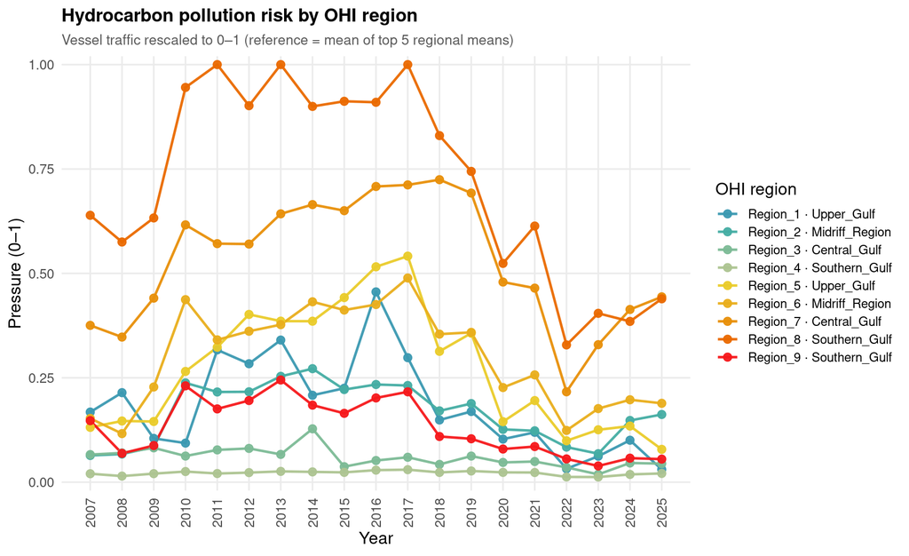

```r
hydrocarbon_trends <- hydrocarbon_pollution_risk %>%
  left_join(region_labels, by = c("rgn_id" = "ohi_rgn")) %>%
  mutate(region_label = factor(region_label, levels = region_labels$region_label))

hydrocarbon_trend_plot <- ggplot(
  hydrocarbon_trends,
  aes(x = year, y = pressure, color = region_label, group = region_label)
) +
  geom_line(linewidth = 0.85, alpha = 0.95) +
  geom_point(size = 2.4, alpha = 0.95) +
  scale_x_continuous(breaks = scales::breaks_width(1)) +
  scale_y_continuous(limits = c(0, 1), expand = expansion(mult = c(0.02, 0.02))) +
  scale_color_manual(values = region_palette, name = "OHI region") +
  labs(
    title = "Hydrocarbon pollution risk by OHI region",
    subtitle = "Vessel traffic rescaled to 0–1 (reference = mean of top 5 regional means)",
    x = "Year",
    y = "Pressure (0–1)"
  ) +
  theme_minimal(base_size = 12) +
  theme(
    plot.title = element_text(face = "bold", size = 13),
    plot.subtitle = element_text(color = "grey35", size = 10),
    panel.grid.minor = element_blank(),
    panel.grid.major = element_line(color = "grey92"),
    axis.text.x = element_text(angle = 90, hjust = 1, vjust = 0.5),
    legend.key.height = unit(0.45, "cm"),
    legend.text = element_text(size = 9)
  )

hydrocarbon_fig_path <- file.path(figures_dir, "hydrocarbon_pollution_risk_trend.png")
ggsave(
  hydrocarbon_fig_path,
  plot = hydrocarbon_trend_plot,
  width = 9,
  height = 5.5,
  dpi = 300,
  bg = "white"
)

hydrocarbon_trend_plot
```

## Ghost gear risk (rescaled ghost gear pressure)

Rescale **ghost gear** regional means to **0–1**:

1. Reference = mean of the **top 5** regional mean values across all regions and years.
2. `pressure = min(mean / reference, 1)`.

```r
ghost_gear_tbl <- read_csv(here("_pressures/vessels/data/ghost_gear_mean_by_ohi_rgn.csv"))
top5_means <- ghost_gear_tbl %>%
  arrange(desc(mean)) %>%
  slice_head(n = 5)

ghost_gear_ref <- mean(top5_means$mean)

ghost_gear_risk <- ghost_gear_tbl %>%
  transmute(
    rgn_id = ohi_rgn,
    year = year,
    pressure = pmin(mean / ghost_gear_ref, 1)
  ) %>%
  arrange(year, rgn_id)

output_dir <- here("_pressures/vessels/output")
dir.create(output_dir, showWarnings = FALSE, recursive = TRUE)

ghost_gear_out <- file.path(output_dir, "ghost_gear_risk.csv")
write_csv(ghost_gear_risk, ghost_gear_out)

message(
  "Ghost gear reference (mean of top 5 regional means): ",
  signif(ghost_gear_ref, 5)
)
```

```
## Ghost gear reference (mean of top 5 regional means): 2.8868
```

```r
message("Wrote ", nrow(ghost_gear_risk), " rows → ", ghost_gear_out)
```

```
## Wrote 171 rows → /home/frazier/ohi_goc_prep/_pressures/vessels/output/ghost_gear_risk.csv
```

```r
top5_means %>%
  select(ohi_rgn, year, mean) %>%
  mutate(rank = row_number())
```

```
## # A tibble: 5 × 4
##   ohi_rgn   year  mean  rank
##   <chr>    <dbl> <dbl> <int>
## 1 Region_8  2017  3.35     1
## 2 Region_8  2011  2.90     2
## 3 Region_8  2013  2.90     3
## 4 Region_8  2010  2.65     4
## 5 Region_8  2015  2.63     5
```

```r
ghost_gear_risk
```

```
## # A tibble: 171 × 3
##    rgn_id    year pressure
##    <chr>    <dbl>    <dbl>
##  1 Region_1  2007   0.184
##  2 Region_2  2007   0.0615
##  3 Region_3  2007   0.0503
##  4 Region_4  2007   0.0199
##  5 Region_5  2007   0.136
##  6 Region_6  2007   0.118
##  7 Region_7  2007   0.266
##  8 Region_8  2007   0.598
##  9 Region_9  2007   0.148
## 10 Region_1  2008   0.227
## # ℹ 161 more rows
```

## Ghost gear risk — regional trend plot

```r
ghost_gear_trends <- ghost_gear_risk %>%
  left_join(region_labels, by = c("rgn_id" = "ohi_rgn")) %>%
  mutate(region_label = factor(region_label, levels = region_labels$region_label))

ghost_gear_trend_plot <- ggplot(
  ghost_gear_trends,
  aes(x = year, y = pressure, color = region_label, group = region_label)
) +
  geom_line(linewidth = 0.85, alpha = 0.95) +
  geom_point(size = 2.4, alpha = 0.95) +
  scale_x_continuous(breaks = scales::breaks_width(1)) +
  scale_y_continuous(limits = c(0, 1), expand = expansion(mult = c(0.02, 0.02))) +
  scale_color_manual(values = region_palette, name = "OHI region") +
  labs(
    title = "Ghost gear risk by OHI region",
    subtitle = "Rescaled to 0–1 (reference = mean of top 5 regional means)",
    x = "Year",
    y = "Pressure (0–1)"
  ) +
  theme_minimal(base_size = 12) +
  theme(
    plot.title = element_text(face = "bold", size = 13),
    plot.subtitle = element_text(color = "grey35", size = 10),
    panel.grid.minor = element_blank(),
    panel.grid.major = element_line(color = "grey92"),
    axis.text.x = element_text(angle = 90, hjust = 1, vjust = 0.5),
    legend.key.height = unit(0.45, "cm"),
    legend.text = element_text(size = 9)
  )

ghost_gear_fig_path <- file.path(figures_dir, "ghost_gear_risk_trend.png")
ggsave(
  ghost_gear_fig_path,
  plot = ghost_gear_trend_plot,
  width = 9,
  height = 5.5,
  dpi = 300,
  bg = "white"
)
message("Wrote figure → ", ghost_gear_fig_path)
```

```
## Wrote figure → /home/frazier/ohi_goc_prep/_pressures/vessels/figures/ghost_gear_risk_trend.png
```

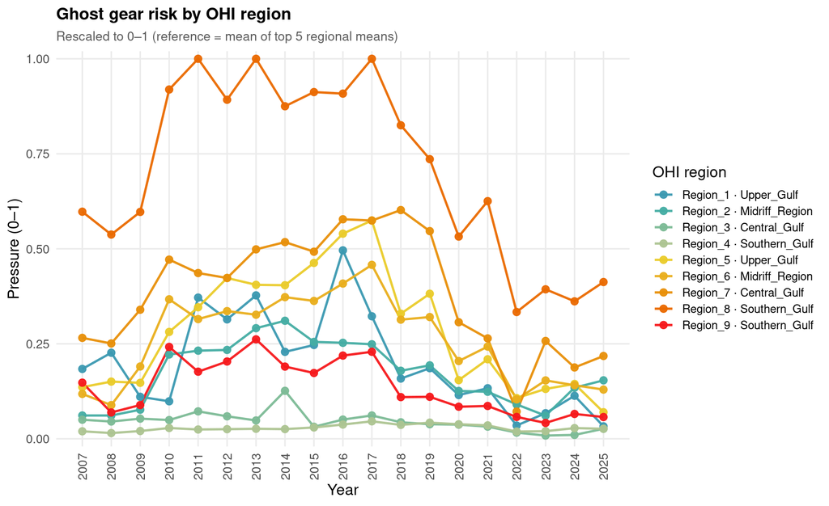

```r
ghost_gear_trend_plot
```